# Biostat 203B Homework 4 (Draft)

Due Mar 12 @ 11:59PM

Load database libraries and the tidyverse frontend:

```r
library(tidyverse)
library(lubridate)
library(miceRanger)
library(mice)
library(fastDummies)
```

## Q1. Missing data

Through the Shiny app developed in HW3, we observe abundant missing values in the MIMIC-IV ICU cohort we created. In this question, we use multiple imputation to obtain a data set without missing values.

0. Read following tutorials on the R package miceRanger for imputation: https://github.com/farrellday/miceRanger, https://cran.r-project.org/web/packages/miceRanger/vignettes/miceAlgorithm.html.

   A more thorough book treatment of the practical imputation strategies is the book [*Flexible Imputation of Missing Data*](https://stefvanbuuren.name/fimd/) by Stef van Buuren.
1. Explain the jargon MCAR, MAR, and MNAR.

If the probability of being missing is the same for all cases, then the data are said to be missing completely at random (MCAR). If the probability of being missing is the same only within groups defined by the observed data, then the data are missing at random (MAR) If neither MCAR nor MAR holds, then we speak of missing not at random (MNAR). In the literature one can also find the term NMAR (not missing at random) for the same concept.

2. Explain in a couple of sentences how the Multiple Imputation by Chained Equations (MICE) work.

Step 1: A simple imputation, such as imputing the mean, is performed for every missing value in the dataset. These mean imputations can be thought of as “place holders.”

Step 2: The “place holder” mean imputations for one variable (“var”) are set back to missing.

Step 3: The observed values from the variable “var” in Step 2 are regressed on the other variables in the imputation model, which may or may not consist of all of the variables in the dataset.

Step 4: The missing values for “var” are then replaced with predictions (imputations) from the regression model.

Step 5: Steps 2–4 are then repeated for each variable that has missing data.

Step 6: Steps 2–4 are repeated for a number of cycles, with the imputations being updated at each cycle.

3. Perform a data quality check of the ICU stays data. Discard variables with substantial missingness, say >5000 `NA`s. Replace apparent data entry errors by `NA`s.

```r
library(naniar)
```

```r
require(miceRanger)
set.seed(1)

# Load data
icu <- readRDS("./icu_cohort-2.rds")

 icu %>%
   gg_miss_var()
```

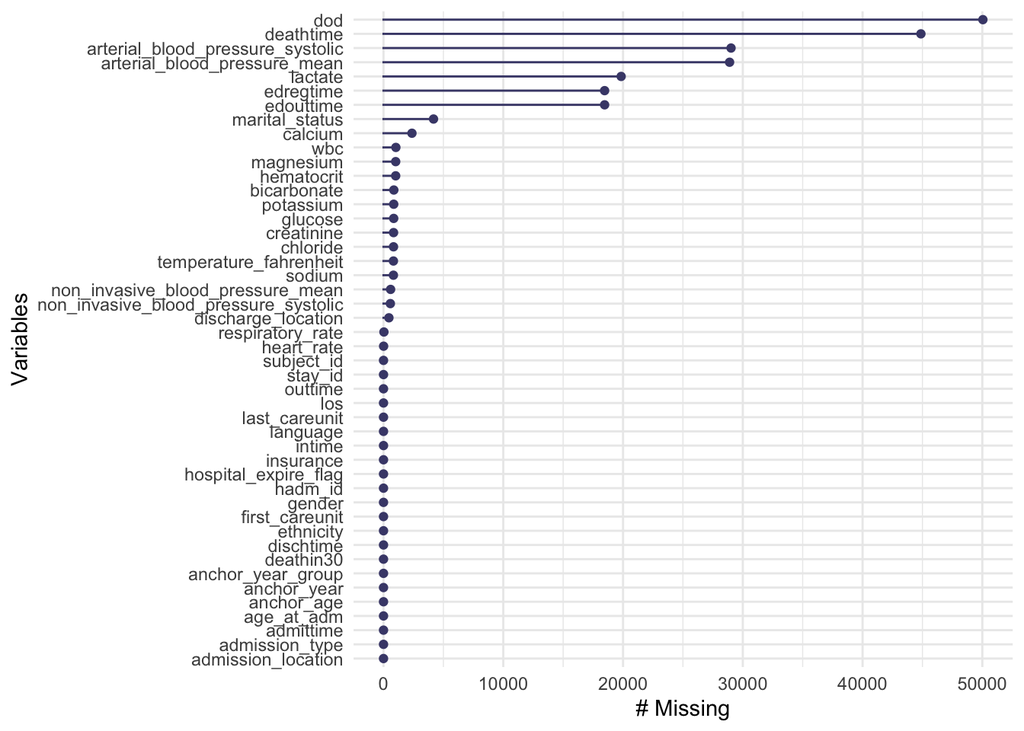

```r
 icu %>%
   select(-dod, -deathtime, -arterial_blood_pressure_systolic,
          -arterial_blood_pressure_mean, -lactate, -edregtime, -edouttime) %>%
   print(width = Inf) -> icu_s
```

```
## # A tibble: 50,048 x 39
##    subject_id  hadm_id  stay_id first_careunit
##         <int>    <int>    <int> <chr>
##  1   10000980 26913865 36742749 Medical Intensive Care Unit (MICU)
##  2   10004733 27411876 37003946 Medical/Surgical Intensive Care Unit (MICU/SICU)
##  3   10006821 23295760 30272829 Medical/Surgical Intensive Care Unit (MICU/SICU)
##  4   10009628 25926192 31786068 Cardiac Vascular Intensive Care Unit (CVICU)
##  5   10012261 27493974 30741264 Trauma SICU (TSICU)
##  6   10012552 27089790 36574633 Cardiac Vascular Intensive Care Unit (CVICU)
##  7   10013419 29669860 31631748 Surgical Intensive Care Unit (SICU)
##  8   10014610 23258342 30950011 Cardiac Vascular Intensive Care Unit (CVICU)
##  9   10016742 29281842 39410091 Surgical Intensive Care Unit (SICU)
## 10   10017308 29888008 36392624 Neuro Surgical Intensive Care Unit (Neuro SICU)
##    last_careunit                                    intime
##    <chr>                                            <dttm>
```

[output cut: 107 more lines]

```r
#We could find there're enter errors in non_invasive_blood_pressure_systolic &
#non_invasive_blood_pressure_mean.
sort(icu$non_invasive_blood_pressure_systolic,decreasing = TRUE)
sort(icu$non_invasive_blood_pressure_mean,decreasing = TRUE)
#The non_invasive_blood_pressure_systolic has enter error for 12262 and non_invasive_blood_pressure_mean has enter errors as 140119 120130 6116 936 .
#Replace them as NA.
```

```r
icu_s$non_invasive_blood_pressure_systolic <- replace(icu_s$non_invasive_blood_pressure_systolic,
        icu_s$non_invasive_blood_pressure_systolic == 12262, NA)
icu_s$non_invasive_blood_pressure_mean <-
  replace(icu_s$non_invasive_blood_pressure_mean,
        icu_s$non_invasive_blood_pressure_mean == 140119, NA)
icu_s$non_invasive_blood_pressure_mean <-
  replace(icu_s$non_invasive_blood_pressure_mean,
        icu_s$non_invasive_blood_pressure_mean == 120130, NA)
```

```r
icu_s$non_invasive_blood_pressure_mean <-
  replace(icu_s$non_invasive_blood_pressure_mean,
        icu_s$non_invasive_blood_pressure_mean == 6116, NA)
icu_s$non_invasive_blood_pressure_mean <-
  replace(icu_s$non_invasive_blood_pressure_mean,
        icu_s$non_invasive_blood_pressure_mean == 936, NA)
```

```r
sort(icu_s$non_invasive_blood_pressure_systolic,decreasing = TRUE)
sort(icu_s$non_invasive_blood_pressure_mean,decreasing = TRUE)
```

```r
icu_s %>%
  select(gender, ethnicity, marital_status, los, age_at_adm, bicarbonate,
         calcium, chloride, creatinine, glucose,
         magnesium, potassium, sodium, hematocrit, wbc, heart_rate,
         non_invasive_blood_pressure_systolic, non_invasive_blood_pressure_mean,
         respiratory_rate, temperature_fahrenheit, deathin30) -> icu_snew
```